# Lesson 172 · Schema tokenization

**One skill:** implement and defend a typed input contract. Real complete F1 snapshot; separate synthetic failure cases. PROVIDED supplies evidence; TODO functions drive the actual audit; CHECK gives feedback; EXIT requires your reasoning. No training or cloud access. Author-reference results below are not your kernel results.

**One skill:** turn a declared database schema into reproducible typed inputs, without learning preprocessing from held-out rows. Core lesson: about 15 minutes; coding lab: 35–50 minutes.

[Lesson 171](https://avistian.github.io/relational/lessons/0171-corpus-of-databases.html) established which database bytes and relationships we have. It did not specify what a model should receive for a cell. Here we build that input contract. Lesson 173 will use such inputs to define training objectives.

## 1 · Separate the value from its role

A model input needs both the observed value and the policy for interpreting it. Reuse the corpus identities from Lesson 171; assigning a token does not change which source supplied the row.

> **In plain terms.** A database stores values. A tokenizer says what each value means, how to represent it, and which information must stay hidden.

## 2 · An integer is not a meaning

A **storage dtype** describes how bytes are represented: integer, floating point or string. A **semantic type** describes how we use a value: quantity, category, text, timestamp or key. A **column role** describes its database function: feature, primary key, foreign key or event clock.

**Worked example.** The integer `7` could be a driver ID, a lap count or a status code. Subtracting the mean driver ID has no meaning for an identity link. A lap count has a meaningful magnitude. A status code names a category; code 8 need not mean “one more” than code 7.

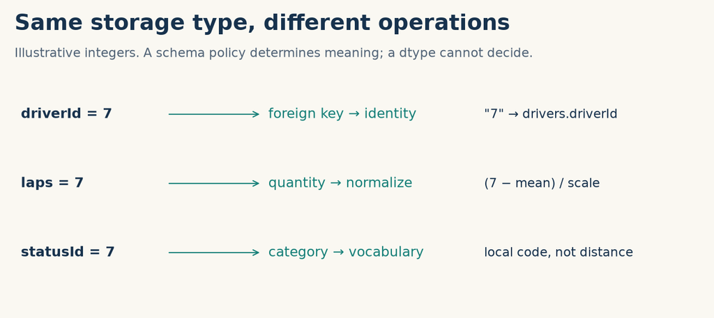

Illustrative equal integers route to different handlers. Keys preserve identity, quantities preserve magnitude, and category codes are local labels. Scroll horizontally on narrow screens.

Our [explicit schema](https://avistian.github.io/relational/labs/evidence/l172/schema.json) assigns all **67 columns** a type and a role. For example, race-car `number` is a category, while `laps` is numerical. These are reviewed **course policies**, not meanings proven by the file dtype. Keys come from the [pinned RelBench F1 source](https://avistian.github.io/relational/labs/sources/l171/relbench/datasets/f1.py) and Parquet metadata. An unrecognized type or undeclared column raises an error; the tokenizer does not guess.

A **token** here is a record with a schema descriptor, state and payload. A **payload** is the encoded value. For a column with N rows, the output contains N states and N scalar or string payloads, plus one shared descriptor and fitted preprocessing record. Table and column names identify the descriptor; input column order does not define identity.

| Kind | Course payload | Meaning retained |
| --- | --- | --- |
| Number | `(value − training mean) / training SD` | Magnitude relative to admitted values |
| Category | Sorted training vocabulary code, starting at 1 | Local label; 0 reserved for non-value states |
| Text | Original Unicode string | Content, without a learned embedding |
| Key | Exact identifier string | Identity and declared target table |
| Timestamp | UTC epoch days | Time coordinate; not proof of availability |

Category codes are **local to a column**. Code 2 in one database does not mean the same thing as code 2 elsewhere. Do not feed the code to a model as an ordered quantity. Keys are relation metadata, not magnitude features. Converting a large integer key through floating point can lose identity; the lab checks an ID larger than 2⁵³.

## 3 · Fit once, then transform

**Fitting** derives statistics or vocabulary from admitted rows. **Transforming** applies that frozen state to a value. If a held-out value changes, the fitted state must stay identical.

**Worked example.** Admitted values are `10, 20, 30`. Their mean is 20. Their population variance is `(100 + 0 + 100) / 3`; their standard deviation is about 8.164966. The value 20 becomes zero. A fourth, held-out value of 999 must not change that calculation.

Predict: what happens to the encoding of the unchanged value 20 if we incorrectly include 999 in the fit?

Notebook intervention below: change the held-out value and compare admitted-only with all-row fit. Correct fit stays mean 20, SD 8.164966; leaky fit changes.

The implementation makes the boundary visible:

```
train = values[admitted].dropna()
mean = train.mean() if len(train) else 0.0
scale = train.std(ddof=0) if len(train) else 1.0
scale = scale if scale > 0 else 1.0
payload = (observed_value - mean) / scale
```

For this audit, rows in time-bearing tables are admitted only when `date < 2005-01-01`. Untimed tables admit **zero rows for fitting**. Their numerical defaults are mean 0 and scale 1; their category vocabulary is empty. These defaults are explicit policy, not learned estimates. All non-null categories in those tables consequently become UNKNOWN. Empty-fit counts remain visible in the report.

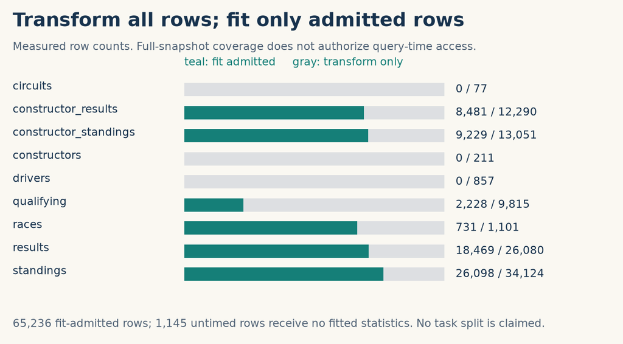

Measured full-snapshot row counts. Teal rows are admitted to fitting; all rows are transformed. Untimed tables admit zero rows. This is not a query availability certificate. Scroll horizontally on narrow screens.

> **Scope check.** We transform the entire stored snapshot to audit coverage. That does not grant a prediction access to every token. Event-time admission is a course fit policy, not a task-label split or proof of historical availability. The three untimed tables remain unresolved. A later query sampler must enforce its own cutoff and information policy.

## 4 · Zero needs a state

**MISSING** means the source has no value. **MASKED** means we deliberately hide a value, for example to make it a prediction target. **UNKNOWN** means a category is observed but absent from the fitted vocabulary. **VALUE** means an observed value has a supported encoding.

Predict: should unseen and masked categories share a state? Explain before checking.

All three non-value category states use payload zero. The state tells them apart. Masking has priority even if the source was null. It erases the payload before any value-dependent encoding; changing a hidden raw value must not change the output. This is an input contract, not yet a loss function.

**The same zero, four different meanings.** Fit a numerical column on `[10,20,30]`, and a category column on `red, blue`. Then transform these cells:

| Cell | State | Payload |
| --- | --- | --- |
| Observed number 20 | VALUE | 0 |
| Absent number | MISSING | 0 |
| Number 20, hidden | MASKED | 0 |
| Observed category green | UNKNOWN | 0 |

The first zero is a real standardized value: 20 equals the fitted mean. The other zeros carry no observed value payload. Dropping the state would make these inputs indistinguishable. **Transfer check:** deliberately mask a null cell or the unknown category `green`. Both become MASKED with zero payload, because masking takes priority over source-dependent states. An unseen numerical value, in contrast, can still be VALUE; UNKNOWN here refers to categorical vocabulary membership.

Frozen vocabulary a→1,b→2. Known b is VALUE 2; unseen future is UNKNOWN 0; null is MISSING 0; hidden b is MASKED 0.

**Measured worked example.** The next figure follows an actual held-out `results.points` cell. Its fit uses only pre-2005 results. The bottom intervention masks that same cell while keeping its schema name. Numbers are displayed rounded; the report keeps full precision.

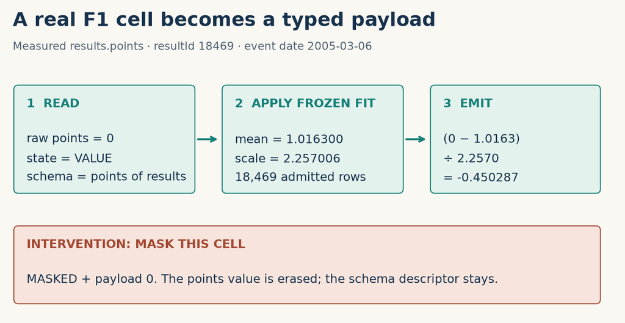

Measured F1 results.points cell. The same raw value, fitted mean and scale produce the displayed payload; masking erases that payload. Rounded display, full precision report. Scroll horizontally on narrow screens.

`resultId=18469` has 0 points on 2005-03-06. With mean 1.016300 and scale 2.257006, its payload is **-0.450287**. This row is transformed but excluded from fitting.

## 5 · What does a learned model add?

Read [Relational Transformer v1, §3.1](https://arxiv.org/html/2510.06377v1#S3.SS1), especially cell token encoding. RT combines datatype-specific value projections with text embeddings of column/table names; masked values use learned vectors. It normalizes timestamps using training statistics and uses a frozen text encoder. Our deterministic payload contract supplies none of those learned components. We retain missing cells explicitly; the paper's context construction includes non-missing feature cells.

This is a **pipeline lesson**, not an RT architecture reproduction. The [source ledger](https://avistian.github.io/relational/labs/sources/l172/source-ledger.json) records the differences. A later model must turn our payloads into compatible vectors and define how to use key links. Shared type handlers alone do not establish cross-database transfer.

## 6 · Complete execution, bounded claims

**Named experiment:** L172 Full F1 Schema-Tokenization Audit. Fixed: the pinned complete F1 archive, every column policy and the pre-2005 fit boundary. Interventions: reorder columns, change held-out number/category values, and mask every cell. Measured: exact coverage, states, fit counts, output hashes and invariant checks. No sampling, optimizer, training seeds or model selection are involved.

| Table | Rows transformed | Columns | Rows admitted to fit |
| --- | --- | --- | --- |
| circuits | 77 | 8 | 0 |
| constructor_results | 12,290 | 5 | 8,481 |
| constructor_standings | 13,051 | 7 | 9,229 |
| constructors | 211 | 4 | 0 |
| drivers | 857 | 7 | 0 |
| qualifying | 9,815 | 7 | 2,228 |
| races | 1,101 | 7 | 731 |
| results | 26,080 | 15 | 18,469 |
| standings | 34,124 | 7 | 26,098 |

**Complete: 97,606 rows, 67 columns, 866,746 cells.** All-table column reordering, all-cell mask erasure and every numerical/category held-out fit intervention pass.

The separate scalar verifier checks every original cell and all **227,716 non-null FK references**. It rejects deliberately wrong learner functions and corrupted evidence identities. Passing these checks establishes the declared transformation contract on this population. It does not establish model accuracy, historical availability or original paper identity.

**Evidence boundary:** full selected tokenization audit COMPLETE; whole-paper reproduction and fresh pretraining NOT_RUN; historical availability NOT_ESTABLISHED; live Colab and deployment NOT_CHECKED. Learner mastery remains PENDING_WRITTEN_DEFENSE.

## 7 · Build it, then defend it

**Next step in the sequence:** [Lesson 173](https://avistian.github.io/relational/lessons/0173-multi-task-pretraining.html) gives these inputs a prediction target and loss. The tokenizer defines what enters the model; the objective defines what it learns to predict.

[Student notebook](https://avistian.github.io/relational/labs/0172-schema-tokenization.ipynb) · [Prepared solution view](https://avistian.github.io/relational/labs/html/0172-schema-tokenization.html) · [Quick reference](https://avistian.github.io/relational/reference/schema-tokenization.html) · [Reproduction commands](https://avistian.github.io/relational/labs/l172-reproduction.md)

Implement three live functions: fit a column on admitted rows; encode values with explicit states; assemble named columns without losing schema identity. The full archive audit calls your implementations. CHECK cells expose the first failure before you run the larger audit. The solution embeds the exact data and source packet and can execute in an empty directory.

**EXIT.** Defend a policy for one unseen table. Explain what can be reused, what must be fitted locally, how key links survive, and which availability evidence is missing. Give a counterexample where a dtype-only rule fails. Predict the outcome before running a held-out-value intervention.

Write your defense before opening the teacher outline; submit it for review.

Tomorrow, reconstruct the four states from memory. In a week, explain why category-code reuse across databases is unsafe. Ask the teacher follow-up questions about any unclear step, or submit your notebook and written defense for review.

```python
# @colab-bootstrap
import os
os.environ.update(OMP_NUM_THREADS="1",OPENBLAS_NUM_THREADS="1",MKL_NUM_THREADS="1")
import base64,hashlib,io,json,zipfile
from pathlib import Path
try:
 import pandas as pd
 import numpy as np
 import pyarrow.parquet as pq
except ImportError as exc:
 raise RuntimeError("Install pandas==3.0.3, pyarrow==24.0.0 and numpy, then rerun") from exc
P=Path("l172-portable");P.mkdir(exist_ok=True)
```

## PROVIDED · Authenticate complete evidence

The packet contains all nine tables and the original archive, schema policies and source provenance. Hashes detect changed bytes, not historical truth. No network is required after installing dependencies.

[output not shown]

## TODO · Fit only admitted rows

Accept values, kind and one strict boolean admission per row. Kinds: number/category/text/key/timestamp. Return kind,fit_rows,fit_nonnull. Numbers add mean and scale using admitted nonnull values and population SD. Empty fit uses0/1; constant uses SD1. Reject nonfinite admitted numbers. Categories add sorted distinct str(value) vocabulary from admitted nonnull rows. Unsupported kind or invalid admission raises ValueError. Do not mutate inputs.

Predict one failing case before you implement this operation.

```python
def fit_column(values, kind, admitted):
    """Fit only admitted nonnull values; empty numerical fit uses (0, 1)."""
    import numpy as np
    import pandas as pd
    if kind not in {'number','category','text','key','timestamp'}:
        raise ValueError('Unsupported semantic type: '+str(kind))
    s=pd.Series(values).reset_index(drop=True)
    flags=list(admitted)
    if len(flags)!=len(s) or any(not isinstance(v,(bool,np.bool_)) for v in flags):
        raise ValueError('Admission must be one boolean per row')
    train=s[pd.Series(flags,dtype=bool)].dropna()
    state=dict(kind=kind,fit_rows=int(sum(flags)),fit_nonnull=len(train))
    if kind=='number':
        try:a=np.asarray(train,dtype=float)
        except (ValueError,TypeError) as exc:raise ValueError('Expected numerical values') from exc
        if not np.isfinite(a).all():raise ValueError('Nonfinite numerical fit value')
        mean=float(a.mean()) if len(a) else 0.
        scale=float(a.std(ddof=0)) if len(a) else 1.
        state.update(mean=mean,scale=scale if scale>0 else 1.)
    if kind=='category':state['vocabulary']=sorted({str(v) for v in train})
    return state
```

```python
# CHECK
f=fit_column(pd.Series([10.,20.,30.,999.]),"number",[True,True,True,False])
assert f["mean"]==20 and abs(f["scale"]-8.16496580927726)<1e-12
print("CHECK: held-out 999 did not enter the fit")
```

```
CHECK: held-out 999 did not enter the fit
```

## TODO · Preserve states and erase masked payloads

Accept values, fitted state, optional strict boolean mask (default all False). Return state and payload lists of the same length. MASKED has priority over source null; otherwise MISSING, then UNKNOWN for unseen category, otherwise VALUE. Non-value payload0 for number/category/timestamp, empty string for text/key. Normalize observed finite numbers with frozen mean/scale; reject invalid/nonfinite numbers. Category codes start1 in vocabulary order. Text/key use str without a float cast. Timestamp uses UTC epoch days. Unsupported kind or wrong mask raises ValueError. Never encode a masked raw value.

Predict one failing case before you implement this operation.

```python
def encode_column(values, fitted, masked=None):
    """State precedes payload: masked values are erased even when originally null."""
    import numpy as np
    import pandas as pd
    s=pd.Series(values).reset_index(drop=True);kind=fitted['kind']
    if kind not in {'number','category','text','key','timestamp'}:raise ValueError('Unsupported semantic type')
    mask=[False]*len(s) if masked is None else list(masked)
    if len(mask)!=len(s) or any(not isinstance(v,(bool,np.bool_)) for v in mask):
        raise ValueError('Mask must be one boolean per row')
    flags=np.asarray(mask,dtype=bool);missing=s.isna().to_numpy();active=~(flags|missing)
    states=np.full(len(s),'VALUE',dtype=object);states[missing]='MISSING';states[flags]='MASKED'
    neutral='' if kind in {'key','text'} else 0.
    payload=np.full(len(s),neutral,dtype=object)
    observed=s[active]
    if kind=='number':
        try:a=np.asarray(observed,dtype=float)
        except (ValueError,TypeError) as exc:raise ValueError('Expected numerical values') from exc
        if not np.isfinite(a).all():raise ValueError('Nonfinite numerical transform value')
        if not np.isfinite(fitted['mean']) or not np.isfinite(fitted['scale']) or fitted['scale']<=0:raise ValueError('Invalid fitted normalization')
        payload[active]=(a-fitted['mean'])/fitted['scale']
    elif kind=='timestamp':
        dates=pd.to_datetime(observed,utc=True,errors='raise')
        payload[active]=((dates-pd.Timestamp('1970-01-01',tz='UTC'))/pd.Timedelta(days=1)).to_numpy()
    elif kind=='category':
        vocab={v:i+1 for i,v in enumerate(fitted['vocabulary'])}
        codes=[vocab.get(str(v),0) for v in observed]
        payload[active]=codes
        positions=np.flatnonzero(active)
        states[positions[np.asarray(codes)==0]]='UNKNOWN'
    else:
        # Never cast key identifiers through floating point: 2**53+1 must survive.
        payload[active]=[str(v) for v in observed]
    return dict(state=states.tolist(),payload=payload.tolist())
```

```python
# CHECK
f=fit_column(pd.Series(["b","a"]),"category",[True,True])
e=encode_column(pd.Series(["b","future",None,"a"]),f,[False,False,False,True])
assert e==dict(state=["VALUE","UNKNOWN","MISSING","MASKED"],payload=[2,0,0,0])
print("CHECK: identical neutral payloads retain different meanings")
```

```
CHECK: identical neutral payloads retain different meanings
```

## TODO · Assemble by schema identity

Accept DataFrame, schema mapping column to descriptor, admitted flags and optional masks mapping column to boolean list. Reject duplicate/missing/extra columns, absent mask names, invalid roles, and primary/foreign keys whose kind is not key. Roles: feature,primary_key,foreign_key,event_time. Iterate names sorted; call your fit_column and encode_column. Return rows and columns. Each column contains copied schema, fitted, state,payload. Preserve descriptor fields, including foreign-key target. Input column order must not affect output.

Predict one failing case before you implement this operation.

```python
def tokenize_table(frame, schema, admitted, masks=None):
    """Canonical column names survive reordering; key roles remain explicit."""
    if not frame.columns.is_unique or set(frame.columns)!=set(schema):
        raise ValueError('Schema must declare every column exactly once')
    masks={} if masks is None else masks
    if set(masks)-set(schema):raise ValueError('Mask names an absent column')
    columns={}
    for name in sorted(schema):
        spec=schema[name]
        if spec.get('role') not in {'feature','primary_key','foreign_key','event_time'}:
            raise ValueError('Unsupported column role')
        if spec['role'] in {'primary_key','foreign_key'} and spec['kind']!='key':
            raise ValueError('Keys must preserve identity, not magnitude')
        fitted=fit_column(frame[name],spec['kind'],admitted)
        columns[name]=dict(schema=dict(spec),fitted=fitted,**encode_column(frame[name],fitted,masks.get(name)))
    return dict(rows=len(frame),columns=columns)
```

```python
# CHECK
frame=pd.DataFrame({"n":[10.,20.],"c":["a","b"]})
spec={"n":dict(kind="number",role="feature"),"c":dict(kind="category",role="feature")}
assert tokenize_table(frame,spec,[True,False])==tokenize_table(frame[["c","n"]],spec,[True,False])
print("CHECK: schema identity survives reordering")
```

```
CHECK: schema identity survives reordering
```

## CHECK · Attack the boundary

This suite calls your live functions. It includes a large integer key, constant and empty numeric fits, unknown/missing/masked categories, wrong shapes, nonfinite values and held-out-value interventions.

```python
def check172(fit,encode,tokenize):
 import pandas as pd
 import numpy as np
 def reject(fn):
  try:fn()
  except ValueError:return
  raise AssertionError('Expected ValueError')
 x=pd.Series([10.,20.,30.,999.]);admit=pd.Series([True,True,True,False])
 fitted=fit(x,'number',admit)
 assert fitted['mean']==20 and np.isclose(fitted['scale'],np.sqrt(200/3))
 changed=x.copy();changed.iloc[3]=-9999
 assert fit(changed,'number',admit)==fitted,'Heldout values changed fit'
 out=encode(pd.Series([20.,None,999.]),fitted,[False,False,True])
 assert out['state']==['VALUE','MISSING','MASKED'] and out['payload']==[0.,0.,0.]
 assert encode(pd.Series([20.,None,-42.]),fitted,[False,False,True])==out,'Masked value leaks'
 cat=fit(pd.Series(['b','a','future',None]),'category',[True,True,False,True])
 assert cat['vocabulary']==['a','b']
 assert encode(pd.Series(['b','future',None,'a']),cat,[False,False,False,True])==dict(state=['VALUE','UNKNOWN','MISSING','MASKED'],payload=[2,0,0,0])
 key=fit(pd.Series([9007199254740993,7],dtype='Int64'),'key',[False,False])
 assert encode(pd.Series([9007199254740993,None],dtype='Int64'),key)['payload']==['9007199254740993','']
 empty=fit(x,'number',[False]*4);assert empty['mean']==0 and empty['scale']==1 and empty['fit_nonnull']==0
 const=fit(pd.Series([4.,4.]),'number',[True,True]);assert const['scale']==1
 frame=pd.DataFrame({'n':[10.,20.],'c':['a','b']});schema={'n':{'kind':'number','role':'feature'},'c':{'kind':'category','role':'feature'}}
 a=tokenize(frame,schema,[True,False]);b=tokenize(frame[['c','n']],schema,[True,False]);assert a==b
 assert a['rows']==2 and list(a['columns'])==['c','n']
 reject(lambda:fit(x,'mystery',admit));reject(lambda:fit(x,'number',[True]))
 reject(lambda:fit(x,'number',[1,1,1,0]));reject(lambda:encode(x,fitted,[False]))
 reject(lambda:tokenize(frame,{'n':schema['n']},[True,True]))
 reject(lambda:tokenize(frame,schema,[True,True],{'absent':[False,False]}))
 reject(lambda:fit(pd.Series([float('inf')]),'number',[True]))
 dt=fit(pd.Series(['1970-01-02',None]),'timestamp',[False,False])
 assert encode(pd.Series(['1970-01-02',None]),dt)['payload']==[1.,0.]
 text=fit(pd.Series(['é',None]),'text',[False,False]);assert encode(pd.Series(['é',None]),text)['payload']==['é','']
 return 'PASS'
```

```python
assert check172(fit_column,encode_column,tokenize_table)=="PASS"
print("Live tokenizer contracts PASS")
```

```
Live tokenizer contracts PASS
```

## PROVIDED · Authenticate and load every table

Read the code: the audit authenticates inputs and calls your live operations. It does not import a hidden model.

```python
def load172(root, manifest):
    import hashlib,json,zipfile
    from pathlib import Path
    import pyarrow.parquet as pq
    root=Path(root)
    for name,digest in manifest['files'].items():
        p=Path(name)
        if p.is_absolute() or '..' in p.parts:raise ValueError('Unsafe input path')
        if hashlib.sha256((root/p).read_bytes()).hexdigest()!=digest:raise ValueError('Input hash mismatch: '+name)
    schema=json.loads((root/'evidence/l172/schema.json').read_text())
    tables={}
    with zipfile.ZipFile(root/'evidence/l171/rel-f1-db.zip') as archive:
        members={n for n in archive.namelist() if n.endswith('.parquet')}
        if members!={'db/'+n+'.parquet' for n in schema}:raise ValueError('Incomplete table population')
        for name,spec in sorted(schema.items()):
            path=root/'evidence/l171/db'/(name+'.parquet')
            if path.read_bytes()!=archive.read('db/'+name+'.parquet'):raise ValueError('Archive member mismatch')
            table=pq.read_table(path);frame=table.to_pandas()
            meta={k:json.loads(table.schema.metadata[k.encode()]) for k in ['pkey_col','time_col','fkey_col_to_pkey_table']}
            if meta['time_col']!=spec['time_col']:raise ValueError('Clock mismatch')
            for c,cs in spec['columns'].items():
                if str(frame[c].dtype)!=cs['storage_dtype']:raise ValueError('Storage dtype mismatch')
                expected='primary_key' if c==meta['pkey_col'] else 'foreign_key' if c in meta['fkey_col_to_pkey_table'] else 'event_time' if c==meta['time_col'] else 'feature'
                if cs['role']!=expected:raise ValueError('Key role mismatch')
                if expected=='foreign_key' and cs['target_table']!=meta['fkey_col_to_pkey_table'][c]:raise ValueError('FK target mismatch')
            tables[name]=frame
    return tables,schema
```

## PROVIDED · Run the full declared audit

Read the code: the audit authenticates inputs and calls your live operations. It does not import a hidden model.

```python
def replay172(root,manifest,fit,encode,tokenize):
    import collections,hashlib,json
    import numpy as np
    import pandas as pd
    tables,schema=load172(root,manifest)
    result=dict(experiment='L172 Full F1 Schema-Tokenization Audit',status='COMPLETE_FULL_SNAPSHOT_TOKENIZATION',tables={},rows=0,cells=0,columns=0,cloud_usd=0,
        historical_availability='NOT_ESTABLISHED',whole_paper_reproduction='NOT_RUN',fresh_pretraining='NOT_RUN',learner='PENDING_WRITTEN_DEFENSE')
    for name,frame in tables.items():
        spec=schema[name];clock=spec['time_col']
        admitted=(frame[clock]<pd.Timestamp(spec['fit_cutoff'])).tolist() if clock else [False]*len(frame)
        tokens=tokenize(frame,spec['columns'],admitted)
        reordered=tokenize(frame[frame.columns[::-1]],spec['columns'],admitted)
        if tokens!=reordered:raise AssertionError('Column reorder changed named tokens')
        digest=hashlib.sha256(json.dumps(tokens,sort_keys=True,allow_nan=False,separators=(',',':')).encode()).hexdigest()
        summaries={}
        for column,out in tokens['columns'].items():
            kind=out['fitted']['kind'];values=frame[column]
            # All rows are exercised with the mask on, including source-null values.
            erased=encode(values,out['fitted'],[True]*len(frame))
            neutral='' if kind in {'key','text'} else 0.
            assert erased['state']==['MASKED']*len(frame) and erased['payload']==[neutral]*len(frame)
            if kind in {'number','category'}:
                mutated=values.astype(object).copy()
                mutated.loc[~np.asarray(admitted,dtype=bool)]=123456789. if kind=='number' else '__FUTURE_ONLY__'
                assert fit(mutated,kind,admitted)==out['fitted'],'Heldout intervention changed fit'
            summaries[column]=dict(kind=kind,role=out['schema']['role'],fit_rows=out['fitted']['fit_rows'],fit_nonnull=out['fitted']['fit_nonnull'],states=dict(sorted(collections.Counter(out['state']).items())),
                fit_sha256=hashlib.sha256(json.dumps(out['fitted'],sort_keys=True,allow_nan=False).encode()).hexdigest())
        if name=='results':
            c='points';out=tokens['columns'][c]
            i=int(np.flatnonzero(~np.asarray(admitted,dtype=bool))[0]);key=frame['resultId'].iloc[i]
            result['worked_trace']=dict(table=name,column=c,row_index=i,resultId=str(key),date=str(frame['date'].iloc[i]),raw=float(frame[c].iloc[i]),mean=out['fitted']['mean'],scale=out['fitted']['scale'],state=out['state'][i],payload=out['payload'][i],fit_rows=sum(admitted))
        result['tables'][name]=dict(rows=len(frame),columns=len(frame.columns),cells=len(frame)*len(frame.columns),admitted_rows=sum(admitted),time_col=clock,availability='NOT_ESTABLISHED',token_sha256=digest,column_audit=summaries)
        result['rows']+=len(frame);result['cells']+=len(frame)*len(frame.columns);result['columns']+=len(frame.columns)
    result['checks']=dict(column_reordering='PASS_ALL_TABLES',all_cell_mask_erasure='PASS',heldout_fit_intervention='PASS_ALL_NUMBER_CATEGORY_COLUMNS')
    return result
```

```python
report=replay172(P,manifest,fit_column,encode_column,tokenize_table)
Path("l172-report.json").write_text(json.dumps(report,indent=2)+"\n")
assert (report["rows"],report["columns"],report["cells"])==(97606,67,866746)
print(report["status"])
display(pd.DataFrame([{ "table":n,"rows":t["rows"],"columns":t["columns"],"fit_rows":t["admitted_rows"]} for n,t in report["tables"].items()]))
print("Real points trace:",report["worked_trace"])
print("Availability:",report["historical_availability"],"| whole paper:",report["whole_paper_reproduction"])
```

```
COMPLETE_FULL_SNAPSHOT_TOKENIZATION
```

|  | table | rows | columns | fit_rows |
| --- | --- | --- | --- | --- |
| 0 | circuits | 77 | 8 | 0 |
| 1 | constructor_results | 12290 | 5 | 8481 |
| 2 | constructor_standings | 13051 | 7 | 9229 |
| 3 | constructors | 211 | 4 | 0 |
| 4 | drivers | 857 | 7 | 0 |
| 5 | qualifying | 9815 | 7 | 2228 |
| 6 | races | 1101 | 7 | 731 |
| 7 | results | 26080 | 15 | 18469 |
| 8 | standings | 34124 | 7 | 26098 |

```
Real points trace: {'table': 'results', 'column': 'points', 'row_index': 18469, 'resultId': '18469', 'date': '2005-03-06 14:00:00', 'raw': 0.0, 'mean': 1.0163002869673508, 'scale': 2.2570062003441236, 'state': 'VALUE', 'payload': -0.4502868830455124, 'fit_rows': 18469}
Availability: NOT_ESTABLISHED | whole paper: NOT_RUN
```

## Intervention · Can the future change the past encoding?

Before executing, predict which fit will change when 999 becomes 300. This synthetic example isolates the mistake; it is not an intervention on the real archive.

```python
for future in [999.,300.]:
 values=pd.Series([10.,20.,30.,future])
 correct=fit_column(values,"number",[True,True,True,False])
 leaky=fit_column(values,"number",[True]*4)
 print("heldout",future,"correct probe",encode_column(pd.Series([20.]),correct),"leaky probe",encode_column(pd.Series([20.]),leaky))
```

```
heldout 999.0 correct probe {'state': ['VALUE'], 'payload': [0.0]} leaky probe {'state': ['VALUE'], 'payload': [-0.5772699679754442]}
heldout 300.0 correct probe {'state': ['VALUE'], 'payload': [0.0]} leaky probe {'state': ['VALUE'], 'payload': [-0.5763708787148327]}
```

## EXIT · Defend the contract

Write 200–400 words: choose an unseen table and assign types/roles; give a dtype-only counterexample; identify allowed fit rows; distinguish three neutral states; explain why local category codes do not establish semantic transfer; name one missing temporal guarantee. Submit code, report and defense to the teacher. Author execution alone does not establish mastery.

```python
defense={k:"" for k in ["new_schema","dtype_counterexample","fit_admission","neutral_states","category_transfer","availability_gap"]}
submission=dict(defense=defense,report_sha256=hashlib.sha256(Path("l172-report.json").read_bytes()).hexdigest(),teacher_review=None,learner="PENDING_WRITTEN_DEFENSE")
Path("l172-submission.json").write_text(json.dumps(submission,indent=2)+"\n")
print("Learner PENDING_WRITTEN_DEFENSE")
```

```
Learner PENDING_WRITTEN_DEFENSE
```

## Reproduction boundary

This notebook executes the complete approved course tokenization audit. The independent scalar oracle is `_verify_l172.py`; exact commands and budget controls are in the protocol. No model objective or trainer is claimed. RT learned embeddings, whole-paper reproduction and fresh pretraining remain NOT_RUN. Live Colab and deployment NOT_CHECKED.